# CellfindR_Vignette

Kevin Yu

2/15/2021

## CellFindR pipeline

This tutorial helps you run cellfindR on your dataset. Please make sure you have Seurat installed (preferably the latest Seurat 3 version and that you run all the functions that are included in the CellFindR.R script file.

Now, please try and load the data, if you have a Seurat object already processed, or if you need a fresh 10x install use the load_data function. For this case, I will be demoing using Tympanic Membrane epithelium of the Mouse dataset from Frumm et al: https://pubmed.ncbi.nlm.nih.gov/33181078/

## load data from scratch

if you only have the barcodes, genes, matrix raw files, please run the seurat tutorial to make a Seurat object or use the load_tenx function provided in the CellfindR wrapper functions, if not skip the next section and load your seurat R data.

```r
## load data from processed RDS
file_loc <- "/Users/kyu/Desktop/02cochlea/TM_Epi"
#load_tenx(file_loc, res = 0.1, proj_name = 'TM_epi', cutoff= 10000, mito = FALSE)
```

```r
## load data from processed RDS
tenx <- readRDS(file = "/Users/kyu/Desktop/02cochlea/TM_Epi/TM_Epi.rds")
proj_name <- 'TM_epi'
```

## set working directory of output data and view data

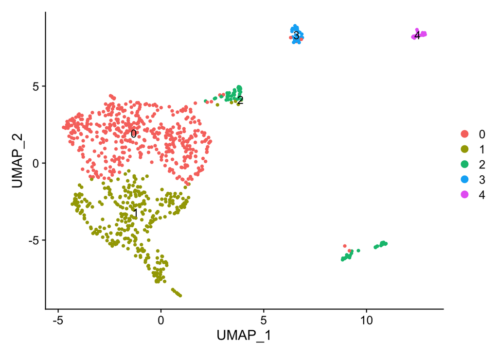

```r
setwd(file_loc)
DimPlot(tenx, reduction = "umap",  label = TRUE)
```

## set initial groups we need to first set the initial groups to do the first layer of analysis, we can use find_res function for cellfindR or you can set a manual seurat resolution depending on what your data looks like.

```r
# cluster first layer
#manual set res for first layer
res <- 0.3
#or find a resolution
#res <- find_res(tenx, initial_res = 0.1, jump = 0.1)
tenx <- FindClusters(tenx, resolution = res)
```

```
## Modularity Optimizer version 1.3.0 by Ludo Waltman and Nees Jan van Eck
##
## Number of nodes: 918
## Number of edges: 27533
##
## Running Louvain algorithm...
## Maximum modularity in 10 random starts: 0.8533
## Number of communities: 7
## Elapsed time: 0 seconds
```

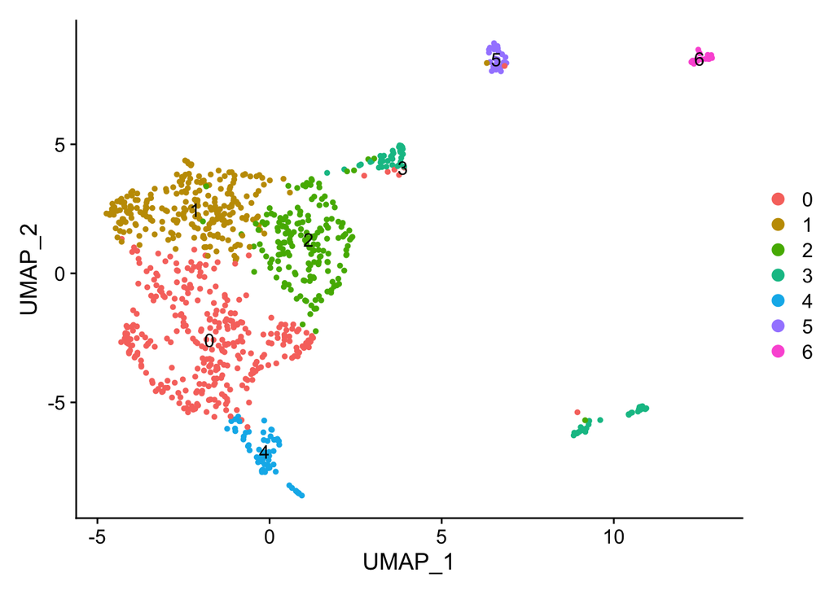

```r
DimPlot(tenx, reduction = "umap",  label = TRUE)
```

## create output folder and run data

we create an output folder for the cellfindr outputs, creating a new directory. Then we can run the file to create a new seurat object with the cellfindr labels.

```r
# create output folder
output_folder <- paste(file_loc, '/', Sys.time(), sep = '')
dir.create(output_folder)

#run cellfindR subclustering analysis
#get subclusters based on initial clustering
tenx_labeled <- sub_clustering(tenx, output_folder, proj_name)
```

```
## [1] "Running subclustering"
## [1] "clustering 0"
```

```
## [1] "Trying 0.1"
```

```
## Modularity Optimizer version 1.3.0 by Ludo Waltman and Nees Jan van Eck
##
## Number of nodes: 320
## Number of edges: 9400
##
## Running Louvain algorithm...
## Maximum modularity in 10 random starts: 0.9000
## Number of communities: 1
## Elapsed time: 0 seconds
## [1] "noclusterfound 0.1"
## [1] "Trying 0.2"
```

```
## Modularity Optimizer version 1.3.0 by Ludo Waltman and Nees Jan van Eck
##
## Number of nodes: 320
## Number of edges: 9400
##
## Running Louvain algorithm...
## Maximum modularity in 10 random starts: 0.8414
## Number of communities: 2
## Elapsed time: 0 seconds
## [1] 0.5373881
## [1] 1.214692
## [1] "ok 0.2"
## [1] "Trying 0.3"
```

```
## Modularity Optimizer version 1.3.0 by Ludo Waltman and Nees Jan van Eck
##
## Number of nodes: 320
## Number of edges: 9400
##
## Running Louvain algorithm...
## Maximum modularity in 10 random starts: 0.7961
## Number of communities: 3
## Elapsed time: 0 seconds
## [1] 1.208033
## [1] 0.643381
## [1] -0.9294579
## [1] "broke 0.3"
## [1] 0.2
```

```
## Modularity Optimizer version 1.3.0 by Ludo Waltman and Nees Jan van Eck
##
## Number of nodes: 320
## Number of edges: 9400
##
## Running Louvain algorithm...
## Maximum modularity in 10 random starts: 0.8414
## Number of communities: 2
## Elapsed time: 0 seconds
## [1] "/Users/kyu/Desktop/02cochlea/TM_Epi/2021-02-15 14:51:06/0"
```

```
## [1] "getting matrix"
```

```
## Finished averaging RNA for cluster 0
## Finished averaging RNA for cluster 1
```

```
## [1] "0"
## [1] "1"
## [1] "0"
## [1] "1"
```

```
## [1] "clustering 0.0"
```

```
## [1] "Trying 0.1"
```

```
## Modularity Optimizer version 1.3.0 by Ludo Waltman and Nees Jan van Eck
##
## Number of nodes: 172
## Number of edges: 4991
##
## Running Louvain algorithm...
## Maximum modularity in 10 random starts: 0.9000
## Number of communities: 1
## Elapsed time: 0 seconds
## [1] "noclusterfound 0.1"
## [1] "Trying 0.2"
```

```
## Modularity Optimizer version 1.3.0 by Ludo Waltman and Nees Jan van Eck
##
## Number of nodes: 172
## Number of edges: 4991
##
## Running Louvain algorithm...
## Maximum modularity in 10 random starts: 0.8176
## Number of communities: 2
## Elapsed time: 0 seconds
## [1] -0.6858133
## [1] 0.5931614
## [1] "broke 0.2"
## [1] 0.1
```

```
## Modularity Optimizer version 1.3.0 by Ludo Waltman and Nees Jan van Eck
##
## Number of nodes: 172
## Number of edges: 4991
##
## Running Louvain algorithm...
## Maximum modularity in 10 random starts: 0.9000
## Number of communities: 1
## Elapsed time: 0 seconds
## [1] "clustering 0.1"
```

```
## [1] "Trying 0.1"
```

```
## Modularity Optimizer version 1.3.0 by Ludo Waltman and Nees Jan van Eck
##
## Number of nodes: 148
## Number of edges: 4213
##
## Running Louvain algorithm...
## Maximum modularity in 10 random starts: 0.9000
## Number of communities: 1
## Elapsed time: 0 seconds
## [1] "noclusterfound 0.1"
## [1] "Trying 0.2"
```

```
## Modularity Optimizer version 1.3.0 by Ludo Waltman and Nees Jan van Eck
##
## Number of nodes: 148
## Number of edges: 4213
##
## Running Louvain algorithm...
## Maximum modularity in 10 random starts: 0.8000
## Number of communities: 1
## Elapsed time: 0 seconds
## [1] "noclusterfound 0.2"
## [1] "Trying 0.3"
```

```
## Modularity Optimizer version 1.3.0 by Ludo Waltman and Nees Jan van Eck
##
## Number of nodes: 148
## Number of edges: 4213
##
## Running Louvain algorithm...
## Maximum modularity in 10 random starts: 0.7445
## Number of communities: 2
## Elapsed time: 0 seconds
## [1] 0.3927877
## [1] 0.8261968
## [1] "ok 0.3"
## [1] "Trying 0.4"
```

```
## Modularity Optimizer version 1.3.0 by Ludo Waltman and Nees Jan van Eck
##
## Number of nodes: 148
## Number of edges: 4213
##
## Running Louvain algorithm...
## Maximum modularity in 10 random starts: 0.6937
## Number of communities: 2
## Elapsed time: 0 seconds
## [1] 0.4665528
## [1] 0.816808
## [1] "ok 0.4"
## [1] "Trying 0.5"
```

```
## Modularity Optimizer version 1.3.0 by Ludo Waltman and Nees Jan van Eck
##
## Number of nodes: 148
## Number of edges: 4213
##
## Running Louvain algorithm...
## Maximum modularity in 10 random starts: 0.6429
## Number of communities: 2
## Elapsed time: 0 seconds
## [1] 0.4665528
## [1] 0.816808
## [1] "ok 0.5"
## [1] "Trying 0.6"
```

```
## Modularity Optimizer version 1.3.0 by Ludo Waltman and Nees Jan van Eck
##
## Number of nodes: 148
## Number of edges: 4213
##
## Running Louvain algorithm...
## Maximum modularity in 10 random starts: 0.6037
## Number of communities: 3
## Elapsed time: 0 seconds
## [1] 0.8245987
## [1] NA
## [1] 0.9047688
## [1] "ok 0.6"
## [1] "Trying 0.7"
```

```
## Modularity Optimizer version 1.3.0 by Ludo Waltman and Nees Jan van Eck
##
## Number of nodes: 148
## Number of edges: 4213
##
## Running Louvain algorithm...
## Maximum modularity in 10 random starts: 0.5691
## Number of communities: 3
## Elapsed time: 0 seconds
## [1] 0.8245987
## [1] NA
## [1] 0.9047688
## [1] "ok 0.7"
## [1] "Trying 0.8"
```

```
## Modularity Optimizer version 1.3.0 by Ludo Waltman and Nees Jan van Eck
##
## Number of nodes: 148
## Number of edges: 4213
##
## Running Louvain algorithm...
## Maximum modularity in 10 random starts: 0.5345
## Number of communities: 3
## Elapsed time: 0 seconds
## [1] 0.8245987
## [1] NA
## [1] 0.9047688
## [1] "ok 0.8"
## [1] "Trying 0.9"
```

```
## Modularity Optimizer version 1.3.0 by Ludo Waltman and Nees Jan van Eck
##
## Number of nodes: 148
## Number of edges: 4213
##
## Running Louvain algorithm...
## Maximum modularity in 10 random starts: 0.5026
## Number of communities: 4
## Elapsed time: 0 seconds
## [1] 0.718662
## [1] 0.8691379
## [1] NA
## [1] -0.5442249
## [1] "broke 0.9"
## [1] 0.8
```

```
## Modularity Optimizer version 1.3.0 by Ludo Waltman and Nees Jan van Eck
##
## Number of nodes: 148
## Number of edges: 4213
##
## Running Louvain algorithm...
## Maximum modularity in 10 random starts: 0.5345
## Number of communities: 3
## Elapsed time: 0 seconds
## [1] "/Users/kyu/Desktop/02cochlea/TM_Epi/2021-02-15 14:51:06/0.1"
```

```
## [1] "getting matrix"
```

```
## Finished averaging RNA for cluster 0
## Finished averaging RNA for cluster 1
## Finished averaging RNA for cluster 2
```

```
## [1] "0"
## [1] "1"
## [1] "2"
## [1] "0"
## [1] "1"
## [1] "2"
```

```
## [1] "clustering 0.1.0"
```

```
## [1] "Trying 0.1"
```

```
## Modularity Optimizer version 1.3.0 by Ludo Waltman and Nees Jan van Eck
##
## Number of nodes: 63
## Number of edges: 1783
##
## Running Louvain algorithm...
## Maximum modularity in 10 random starts: 0.9000
## Number of communities: 1
## Elapsed time: 0 seconds
## [1] "noclusterfound 0.1"
## [1] "Trying 0.2"
```

```
## Modularity Optimizer version 1.3.0 by Ludo Waltman and Nees Jan van Eck
##
## Number of nodes: 63
## Number of edges: 1783
##
## Running Louvain algorithm...
## Maximum modularity in 10 random starts: 0.8000
## Number of communities: 1
## Elapsed time: 0 seconds
## [1] "noclusterfound 0.2"
## [1] "Trying 0.3"
```

```
## Modularity Optimizer version 1.3.0 by Ludo Waltman and Nees Jan van Eck
##
## Number of nodes: 63
## Number of edges: 1783
##
## Running Louvain algorithm...
## Maximum modularity in 10 random starts: 0.7000
## Number of communities: 1
## Elapsed time: 0 seconds
## [1] "noclusterfound 0.3"
## [1] "Trying 0.4"
```

```
## Modularity Optimizer version 1.3.0 by Ludo Waltman and Nees Jan van Eck
##
## Number of nodes: 63
## Number of edges: 1783
##
## Running Louvain algorithm...
## Maximum modularity in 10 random starts: 0.6000
## Number of communities: 1
## Elapsed time: 0 seconds
## [1] "noclusterfound 0.4"
## [1] "Trying 0.5"
```

```
## Modularity Optimizer version 1.3.0 by Ludo Waltman and Nees Jan van Eck
##
## Number of nodes: 63
## Number of edges: 1783
##
## Running Louvain algorithm...
## Maximum modularity in 10 random starts: 0.5000
## Number of communities: 1
## Elapsed time: 0 seconds
## [1] "noclusterfound 0.5"
## [1] "Trying 0.6"
```

```
## Modularity Optimizer version 1.3.0 by Ludo Waltman and Nees Jan van Eck
##
## Number of nodes: 63
## Number of edges: 1783
##
## Running Louvain algorithm...
## Maximum modularity in 10 random starts: 0.4000
## Number of communities: 1
## Elapsed time: 0 seconds
## [1] "noclusterfound 0.6"
## [1] "Trying 0.7"
```

[output not shown]

```
## [1] "Trying 0.1"
```

```
## Modularity Optimizer version 1.3.0 by Ludo Waltman and Nees Jan van Eck
##
## Number of nodes: 35
## Number of edges: 595
##
## Running Louvain algorithm...
## Maximum modularity in 10 random starts: 0.9000
## Number of communities: 1
## Elapsed time: 0 seconds
## [1] "noclusterfound 0.1"
## [1] "Trying 0.2"
```

```
## Modularity Optimizer version 1.3.0 by Ludo Waltman and Nees Jan van Eck
##
## Number of nodes: 35
## Number of edges: 595
##
## Running Louvain algorithm...
## Maximum modularity in 10 random starts: 0.8000
## Number of communities: 1
## Elapsed time: 0 seconds
## [1] "noclusterfound 0.2"
## [1] "Trying 0.3"
```

```
## Modularity Optimizer version 1.3.0 by Ludo Waltman and Nees Jan van Eck
##
## Number of nodes: 35
## Number of edges: 595
##
## Running Louvain algorithm...
## Maximum modularity in 10 random starts: 0.7000
## Number of communities: 1
## Elapsed time: 0 seconds
## [1] "noclusterfound 0.3"
## [1] "Trying 0.4"
```

```
## Modularity Optimizer version 1.3.0 by Ludo Waltman and Nees Jan van Eck
##
## Number of nodes: 35
## Number of edges: 595
##
## Running Louvain algorithm...
## Maximum modularity in 10 random starts: 0.6000
## Number of communities: 1
## Elapsed time: 0 seconds
## [1] "noclusterfound 0.4"
## [1] "Trying 0.5"
```

```
## Modularity Optimizer version 1.3.0 by Ludo Waltman and Nees Jan van Eck
##
## Number of nodes: 35
## Number of edges: 595
##
## Running Louvain algorithm...
## Maximum modularity in 10 random starts: 0.5000
## Number of communities: 1
## Elapsed time: 0 seconds
## [1] "noclusterfound 0.5"
## [1] "Trying 0.6"
```

```
## Modularity Optimizer version 1.3.0 by Ludo Waltman and Nees Jan van Eck
##
## Number of nodes: 35
## Number of edges: 595
##
## Running Louvain algorithm...
## Maximum modularity in 10 random starts: 0.4000
## Number of communities: 1
## Elapsed time: 0 seconds
## [1] "noclusterfound 0.6"
## [1] "Trying 0.7"
```

```
## Modularity Optimizer version 1.3.0 by Ludo Waltman and Nees Jan van Eck
##
## Number of nodes: 35
## Number of edges: 595
##
## Running Louvain algorithm...
## Maximum modularity in 10 random starts: 0.3000
## Number of communities: 1
## Elapsed time: 0 seconds
## [1] "noclusterfound 0.7"
## [1] "noclusterfound 0.7"
```

```
## Modularity Optimizer version 1.3.0 by Ludo Waltman and Nees Jan van Eck
##
## Number of nodes: 35
## Number of edges: 595
##
## Running Louvain algorithm...
## Maximum modularity in 10 random starts: 0.9000
## Number of communities: 1
## Elapsed time: 0 seconds
## [1] "clustering 4.1"
```

```
## [1] "Trying 0.1"
```

```
## Modularity Optimizer version 1.3.0 by Ludo Waltman and Nees Jan van Eck
##
## Number of nodes: 25
## Number of edges: 300
##
## Running Louvain algorithm...
## Maximum modularity in 10 random starts: 0.9000
## Number of communities: 1
## Elapsed time: 0 seconds
## [1] "noclusterfound 0.1"
## [1] "Trying 0.2"
```

```
## Modularity Optimizer version 1.3.0 by Ludo Waltman and Nees Jan van Eck
##
## Number of nodes: 25
## Number of edges: 300
##
## Running Louvain algorithm...
## Maximum modularity in 10 random starts: 0.8000
## Number of communities: 1
## Elapsed time: 0 seconds
## [1] "noclusterfound 0.2"
## [1] "Trying 0.3"
```

```
## Modularity Optimizer version 1.3.0 by Ludo Waltman and Nees Jan van Eck
##
## Number of nodes: 25
## Number of edges: 300
##
## Running Louvain algorithm...
## Maximum modularity in 10 random starts: 0.7000
## Number of communities: 1
## Elapsed time: 0 seconds
## [1] "noclusterfound 0.3"
## [1] "Trying 0.4"
```

```
## Modularity Optimizer version 1.3.0 by Ludo Waltman and Nees Jan van Eck
##
## Number of nodes: 25
## Number of edges: 300
##
## Running Louvain algorithm...
## Maximum modularity in 10 random starts: 0.6000
## Number of communities: 1
## Elapsed time: 0 seconds
## [1] "noclusterfound 0.4"
## [1] "Trying 0.5"
```

```
## Modularity Optimizer version 1.3.0 by Ludo Waltman and Nees Jan van Eck
##
## Number of nodes: 25
## Number of edges: 300
##
## Running Louvain algorithm...
## Maximum modularity in 10 random starts: 0.5000
## Number of communities: 1
## Elapsed time: 0 seconds
## [1] "noclusterfound 0.5"
## [1] "Trying 0.6"
```

```
## Modularity Optimizer version 1.3.0 by Ludo Waltman and Nees Jan van Eck
##
## Number of nodes: 25
## Number of edges: 300
##
## Running Louvain algorithm...
## Maximum modularity in 10 random starts: 0.4000
## Number of communities: 1
## Elapsed time: 0 seconds
## [1] "noclusterfound 0.6"
## [1] "Trying 0.7"
```

```
## Modularity Optimizer version 1.3.0 by Ludo Waltman and Nees Jan van Eck
##
## Number of nodes: 25
## Number of edges: 300
##
## Running Louvain algorithm...
## Maximum modularity in 10 random starts: 0.3000
## Number of communities: 1
## Elapsed time: 0 seconds
## [1] "noclusterfound 0.7"
## [1] "noclusterfound 0.7"
```

```
## Modularity Optimizer version 1.3.0 by Ludo Waltman and Nees Jan van Eck
##
## Number of nodes: 25
## Number of edges: 300
##
## Running Louvain algorithm...
## Maximum modularity in 10 random starts: 0.9000
## Number of communities: 1
## Elapsed time: 0 seconds
## [1] "clustering 5"
```

```
## [1] "Trying 0.1"
```

```
## Modularity Optimizer version 1.3.0 by Ludo Waltman and Nees Jan van Eck
##
## Number of nodes: 26
## Number of edges: 325
##
## Running Louvain algorithm...
## Maximum modularity in 10 random starts: 0.9000
## Number of communities: 1
## Elapsed time: 0 seconds
## [1] "noclusterfound 0.1"
## [1] "Trying 0.2"
```

```
## Modularity Optimizer version 1.3.0 by Ludo Waltman and Nees Jan van Eck
##
## Number of nodes: 26
## Number of edges: 325
##
## Running Louvain algorithm...
## Maximum modularity in 10 random starts: 0.8000
## Number of communities: 1
## Elapsed time: 0 seconds
## [1] "noclusterfound 0.2"
## [1] "Trying 0.3"
```

```
## Modularity Optimizer version 1.3.0 by Ludo Waltman and Nees Jan van Eck
##
## Number of nodes: 26
## Number of edges: 325
##
## Running Louvain algorithm...
## Maximum modularity in 10 random starts: 0.7000
## Number of communities: 1
## Elapsed time: 0 seconds
## [1] "noclusterfound 0.3"
## [1] "Trying 0.4"
```

```
## Modularity Optimizer version 1.3.0 by Ludo Waltman and Nees Jan van Eck
##
## Number of nodes: 26
## Number of edges: 325
##
## Running Louvain algorithm...
## Maximum modularity in 10 random starts: 0.6000
## Number of communities: 1
## Elapsed time: 0 seconds
## [1] "noclusterfound 0.4"
## [1] "Trying 0.5"
```

```
## Modularity Optimizer version 1.3.0 by Ludo Waltman and Nees Jan van Eck
##
## Number of nodes: 26
## Number of edges: 325
##
## Running Louvain algorithm...
## Maximum modularity in 10 random starts: 0.5000
## Number of communities: 1
## Elapsed time: 0 seconds
## [1] "noclusterfound 0.5"
## [1] "Trying 0.6"
```

```
## Modularity Optimizer version 1.3.0 by Ludo Waltman and Nees Jan van Eck
##
## Number of nodes: 26
## Number of edges: 325
##
## Running Louvain algorithm...
## Maximum modularity in 10 random starts: 0.4000
## Number of communities: 1
## Elapsed time: 0 seconds
## [1] "noclusterfound 0.6"
## [1] "Trying 0.7"
```

```
## Modularity Optimizer version 1.3.0 by Ludo Waltman and Nees Jan van Eck
##
## Number of nodes: 26
## Number of edges: 325
##
## Running Louvain algorithm...
## Maximum modularity in 10 random starts: 0.3000
## Number of communities: 1
## Elapsed time: 0 seconds
## [1] "noclusterfound 0.7"
## [1] "noclusterfound 0.7"
```

```
## Modularity Optimizer version 1.3.0 by Ludo Waltman and Nees Jan van Eck
##
## Number of nodes: 26
## Number of edges: 325
##
## Running Louvain algorithm...
## Maximum modularity in 10 random starts: 0.9000
## Number of communities: 1
## Elapsed time: 0 seconds
## [1] "clustering 6"
```

```
## [1] "Trying 0.1"
```

```
## Modularity Optimizer version 1.3.0 by Ludo Waltman and Nees Jan van Eck
##
## Number of nodes: 22
## Number of edges: 231
##
## Running Louvain algorithm...
## Maximum modularity in 10 random starts: 0.9000
## Number of communities: 1
## Elapsed time: 0 seconds
## [1] "noclusterfound 0.1"
## [1] "Trying 0.2"
```

```
## Modularity Optimizer version 1.3.0 by Ludo Waltman and Nees Jan van Eck
##
## Number of nodes: 22
## Number of edges: 231
##
## Running Louvain algorithm...
## Maximum modularity in 10 random starts: 0.8000
## Number of communities: 1
## Elapsed time: 0 seconds
## [1] "noclusterfound 0.2"
## [1] "Trying 0.3"
```

```
## Modularity Optimizer version 1.3.0 by Ludo Waltman and Nees Jan van Eck
##
## Number of nodes: 22
## Number of edges: 231
##
## Running Louvain algorithm...
## Maximum modularity in 10 random starts: 0.7000
## Number of communities: 1
## Elapsed time: 0 seconds
## [1] "noclusterfound 0.3"
## [1] "Trying 0.4"
```

```
## Modularity Optimizer version 1.3.0 by Ludo Waltman and Nees Jan van Eck
##
## Number of nodes: 22
## Number of edges: 231
##
## Running Louvain algorithm...
## Maximum modularity in 10 random starts: 0.6000
## Number of communities: 1
## Elapsed time: 0 seconds
## [1] "noclusterfound 0.4"
## [1] "Trying 0.5"
```

```
## Modularity Optimizer version 1.3.0 by Ludo Waltman and Nees Jan van Eck
##
## Number of nodes: 22
## Number of edges: 231
##
## Running Louvain algorithm...
## Maximum modularity in 10 random starts: 0.5000
## Number of communities: 1
## Elapsed time: 0 seconds
## [1] "noclusterfound 0.5"
## [1] "Trying 0.6"
```

```
## Modularity Optimizer version 1.3.0 by Ludo Waltman and Nees Jan van Eck
##
## Number of nodes: 22
## Number of edges: 231
##
## Running Louvain algorithm...
## Maximum modularity in 10 random starts: 0.4000
## Number of communities: 1
## Elapsed time: 0 seconds
## [1] "noclusterfound 0.6"
## [1] "Trying 0.7"
```

```
## Modularity Optimizer version 1.3.0 by Ludo Waltman and Nees Jan van Eck
##
## Number of nodes: 22
## Number of edges: 231
##
## Running Louvain algorithm...
## Maximum modularity in 10 random starts: 0.3000
## Number of communities: 1
## Elapsed time: 0 seconds
## [1] "noclusterfound 0.7"
## [1] "noclusterfound 0.7"
```

```
## Modularity Optimizer version 1.3.0 by Ludo Waltman and Nees Jan van Eck
##
## Number of nodes: 22
## Number of edges: 231
##
## Running Louvain algorithm...
## Maximum modularity in 10 random starts: 0.9000
## Number of communities: 1
## Elapsed time: 0 seconds
```

```r
# save file
saveRDS(tenx_labeled, file = paste(output_folder,'/', proj_name, "_labeled.rds", sep = ''))

# load updated file
tenx_labeled <- readRDS(paste(output_folder,'/', proj_name, "_labeled.rds", sep = ''))
```

## get the output matrices

now that cellfindr has finished running you can get the special matrix data by running the get_analysis tool getting the stats files, the matrice files as well as the data qualities violin plots.

```r
get_analysis(tenx_labeled, output_folder, proj_name)
```

```
## [1] "getting matrix"
```

```
## Finished averaging RNA for cluster 0.0
```

```
## Finished averaging RNA for cluster 0.1.0
```

```
## Finished averaging RNA for cluster 0.1.1
```

```
## Finished averaging RNA for cluster 0.1.2
```

```
## Finished averaging RNA for cluster 1
```

```
## Finished averaging RNA for cluster 2.0
```

```
## Finished averaging RNA for cluster 2.1
```

```
## Finished averaging RNA for cluster 3.0
```

```
## Finished averaging RNA for cluster 3.1
```

```
## Finished averaging RNA for cluster 3.2
```

```
## Finished averaging RNA for cluster 3.3
```

```
## Finished averaging RNA for cluster 4.0
```

```
## Finished averaging RNA for cluster 4.1
```

```
## Finished averaging RNA for cluster 5
```

```
## Finished averaging RNA for cluster 6
```

```
## [1] "0.0"
## [1] "0.1.0"
## [1] "0.1.1"
## [1] "0.1.2"
## [1] "1"
## [1] "2.0"
## [1] "2.1"
## [1] "3.0"
## [1] "3.1"
## [1] "3.2"
## [1] "3.3"
## [1] "4.0"
## [1] "4.1"
## [1] "5"
## [1] "6"
```

[output cut: 16 more lines]

```
## Finished averaging RNA for cluster 0
```

```
## Finished averaging RNA for cluster 1
```

```
## Finished averaging RNA for cluster 2
```

```
## Finished averaging RNA for cluster 3
```

```
## Finished averaging RNA for cluster 4
```

```
## Finished averaging RNA for cluster 5
```

```
## Finished averaging RNA for cluster 6
```

```
## [1] "0"
## [1] "1"
## [1] "2"
## [1] "3"
## [1] "4"
## [1] "5"
## [1] "6"
## [1] "0"
## [1] "1"
## [1] "2"
## [1] "3"
## [1] "4"
## [1] "5"
## [1] "6"
```